# Exercício 2 - Workbook de Ecologia de Paisagens

Tutorial de Configuração e Ferramenta de Trabalho

Autor

Felipe Melo

Data de Publicação

27 de março de 2026

# 1 Introdução

Neste tutorial você vai aprender a criar seu próprio **Projeto Quarto** — uma ferramenta poderosa que combina texto, código R e resultados em um único documento reproduzível. Ao final, você terá um projeto pessoal que servirá como seu **diário de aprendizagem** e portfólio de análises durante a disciplina.

**NotaO que é Quarto?**

[Quarto](https://quarto.org/) é um sistema de publicação científica e técnica que permite misturar texto em Markdown com código R (ou Python, Julia…) em um mesmo arquivo `.qmd`. O resultado pode ser exportado como HTML, PDF, slides e muito mais — incluindo um **website completo** como este que você está lendo agora.

# 2 Pré-requisitos

Antes de começar, certifique-se de ter instalado:

| Software | Para que serve | Link |
| --- | --- | --- |
| **R** (≥ 4.0) | Linguagem de análise de dados | [cran.r-project.org](https://cran.r-project.org/) |
| **RStudio** (≥ 2022.07) | Ambiente de desenvolvimento | [posit.co/rstudio](https://posit.co/download/rstudio-desktop/) |
| **Quarto CLI** | Motor de renderização | [quarto.org/docs/get-started](https://quarto.org/docs/get-started/) |

**DicaJá instalei R e RStudio — preciso instalar o Quarto separadamente?**

Versões recentes do RStudio já incluem o Quarto embutido. Para checar se funciona, abra o RStudio e vá em **File → New File → Quarto Document…**. Se a opção aparecer, você já está pronto!

# 3 Criando seu Projeto Quarto

## 3.1 Passo 1: Abrir o RStudio

Abra o RStudio. Você verá a interface dividida em painéis:

- **Esquerda superior**: Editor de código/texto
- **Esquerda inferior**: Console do R
- **Direita superior**: Ambiente (objetos carregados)
- **Direita inferior**: Arquivos, Gráficos, Help

## 3.2 Passo 2: Criar um novo Projeto

Um **Projeto** no RStudio organiza todos os seus arquivos em uma pasta única, evitando problemas com caminhos de arquivos.

1. No menu superior, clique em **File → New Project…**
2. Selecione **New Directory**
3. Selecione **Quarto Website** *(esta é a opção ideal para um blog/diário de aprendizagem)*
4. Em **Directory name**, escreva seu nome sem espaços, por exemplo: `diario_ecologia_joao`
5. Em **Create project as subdirectory of**, escolha uma pasta de fácil acesso (ex: Documentos ou Desktop)
6. Clique em **Create Project**

**ImportanteDica de nomenclatura**

Use apenas letras minúsculas, números e underscores `_` no nome do projeto. **Evite** espaços, acentos e caracteres especiais. Exemplo ruim: `Diário João 2026`. Exemplo bom: `diario_joao_2026`.

## 3.3 Passo 3: Conhecer a estrutura de arquivos

Após criar o projeto, o RStudio abrirá automaticamente e você verá no painel **Files** (canto inferior direito) uma estrutura como esta:

```
diario_joao_2026/
├── _quarto.yml          ← Configurações globais do site
├── index.qmd            ← Página inicial (obrigatório!)
├── about.qmd            ← Página "Sobre mim"
├── styles.css           ← Estilos visuais (pode ignorar por ora)
└── diario_joao_2026.Rproj  ← Arquivo do projeto RStudio
```

**NotaO arquivo `_quarto.yml` é o cérebro do site**

É nele que você define o título, a barra de navegação, o tema visual e outras configurações globais. Veremos como editá-lo mais adiante.

# 4 Entendendo os arquivos principais

## 4.1 O arquivo `_quarto.yml`

Abra o arquivo `_quarto.yml` clicando nele no painel Files. Ele se parecerá com isto:

```yaml
project:
  type: website

website:
  title: "diario_joao_2026"
  navbar:
    left:
      - href: index.qmd
        text: Início
      - about.qmd

format:
  html:
    theme: cosmo
    css: styles.css
    toc: true
```

**Personalize agora:** substitua o `title` pelo nome do seu projeto, por exemplo:

```yaml
website:
  title: "Diário de Ecologia de Paisagens — João Silva"
```

## 4.2 O arquivo `index.qmd` (sua página inicial)

Este é o arquivo mais importante — é a primeira página que qualquer visitante verá. Abra-o. Você verá dois componentes:

**O cabeçalho YAML** (entre os `---`):

```yaml
---
title: "diario_joao_2026"
---
```

**O corpo em Markdown** (abaixo do segundo `---`):

```markdown
This is a Quarto website.

To learn more about Quarto websites visit <https://quarto.org/docs/websites>.
```

Substitua todo o conteúdo pelo seu texto de apresentação (veja o exemplo no Seção 7).

# 5 Escrevendo em Markdown

O Quarto usa **Markdown** para formatação de texto. É uma linguagem muito simples:

## 5.1 Formatação básica

```markdown
# Título de nível 1
## Título de nível 2
### Título de nível 3

**negrito**
*itálico*
~~tachado~~

- Item de lista
- Outro item
  - Sub-item

1. Lista numerada
2. Segundo item
```

O resultado será:

**negrito**, *itálico*, tachado

- Item de lista
- Outro item
  - Sub-item

## 5.2 Links e imagens

```markdown
[Texto do link](https://quarto.org)

![Legenda da imagem](caminho/para/imagem.png)
```

## 5.3 Callouts (caixas de destaque)

Os callouts são muito úteis para destacar informações:

```markdown
::: {.callout-note}
## Título da nota
Conteúdo da nota aqui.
:::

::: {.callout-tip}
Dica importante!
:::

::: {.callout-warning}
Atenção a este ponto.
:::
```

O resultado será:

**NotaTítulo da nota**

Conteúdo da nota aqui.

**Dica**

Dica importante!

**Aviso**

Atenção a este ponto.

# 6 Adicionando código R

A grande vantagem do Quarto é poder misturar texto e código R. O código vai dentro de **blocos de código** (*code chunks*):

## 6.1 Criando um bloco de código

Para inserir um bloco R, use o atalho **Ctrl+Alt+I** (Windows/Linux) ou **Cmd+Option+I** (Mac), ou escreva manualmente:

````markdown
```{r}
# Seu código R aqui
2 + 2
```
````

O resultado será

**Código**

```r
# Seu código R aqui
2 + 2
```

```
[1] 4
```

## 6.2 Opções de blocos

Você pode controlar o comportamento de cada bloco com opções:

````markdown
```{r}
#| echo: true       # Mostra o código (padrão: true)
#| eval: true       # Executa o código (padrão: true)
#| warning: false   # Oculta avisos
#| message: false   # Oculta mensagens
#| fig-cap: "Meu gráfico"  # Legenda para figuras

plot(1:10)
```
````

## 6.3 Exemplo prático: um gráfico ecológico

Copie e cole este exemplo no seu `index.qmd`:

**Código**

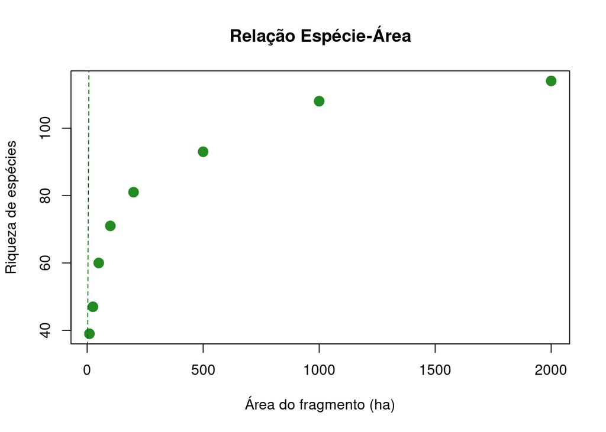

Distribuição hipotética de espécies por fragmento florestal

```r
# Dados simulados de riqueza de espécies em fragmentos
set.seed(42)
area_fragmento <- c(10, 25, 50, 100, 200, 500, 1000, 2000)
riqueza        <- round(15 * log(area_fragmento) + rnorm(8, 0, 3))

# Gráfico simples de relação espécie-área
plot(
  area_fragmento, riqueza,
  xlab = "Área do fragmento (ha)",
  ylab = "Riqueza de espécies",
  main = "Relação Espécie-Área",
  pch  = 19,
  col  = "forestgreen",
  cex  = 1.5
)

# Linha de tendência
abline(lm(riqueza ~ log(area_fragmento)), col = "darkgreen", lty = 2)
```

# 7 Personalizando seu projeto

## 7.1 Exemplo de `index.qmd` personalizado

Substitua o conteúdo do seu `index.qmd` por algo como:

```markdown
---
title: "Diário de Ecologia de Paisagens"
subtitle: "BO-304 | UFPE | 2026.1"
author: "João Silva"
---

## Sobre este diário

Este site é meu portfólio pessoal da disciplina **Ecologia de Paisagens**
(BO-304) da Universidade Federal de Pernambuco, ministrada pelo
Prof. Felipe Melo.

Aqui você encontrará:

- 📓 Anotações das aulas
- 📊 Relatórios das análises em R
- 🌿 Reflexões sobre Ecologia de Paisagens

## Sobre mim

Sou estudante de pós-graduação no Departamento de Botânica do Centro
de Biociências — UFPE. Minha pesquisa aborda...

*(complete com suas informações)*
```

## 7.2 Adicionando uma nova página

Para criar uma nova página (ex: um relatório de análise):

1. No menu, clique em **File → New File → Quarto Document…**
2. Nomeie o arquivo (ex: `relatorio_aula1.qmd`)
3. Salve na pasta raiz do seu projeto

Depois, adicione a página na barra de navegação do `_quarto.yml`:

```yaml
website:
  navbar:
    left:
      - href: index.qmd
        text: Início
      - href: relatorio_aula1.qmd
        text: "Relatório — Aula 1"
      - about.qmd
```

# 8 Renderizando o site

## 8.1 Pré-visualizar localmente

Para ver como seu site ficará, clique no botão **Render** (ou pressione **Ctrl+Shift+K**) com qualquer arquivo `.qmd` aberto.

Alternativamente, no Console do R, execute:

```r
quarto::quarto_preview()
```

Isso abrirá uma prévia no seu navegador padrão que **se atualiza automaticamente** conforme você edita os arquivos.

## 8.2 Renderizar o site completo

Para gerar todos os arquivos HTML do site:

```r
quarto::quarto_render()
```

Os arquivos gerados ficam na pasta `_site/` (ou `docs/`, dependendo da configuração).

# 9 Publicando no GitHub Pages

Esta seção cobre **tudo** que você precisa para colocar seu site no ar, desde a criação da conta no GitHub até o fluxo de atualização contínua. Siga cada passo na ordem indicada — pular etapas é a causa mais comum de problemas.

**NotaO que é GitHub Pages?**

[GitHub Pages](https://pages.github.com/) é um serviço gratuito que transforma arquivos HTML armazenados em um repositório GitHub em um site publicamente acessível. Para nós, funciona assim: o Quarto gera os HTMLs localmente → você envia para o GitHub → o GitHub Pages publica automaticamente em um endereço `*.github.io`.

## 9.1 Pré-requisitos

Você precisará instalar e configurar três coisas antes de começar:

### 9.1.1 A. Criar uma conta no GitHub

1. Acesse github.com e clique em **Sign up**
2. Escolha um nome de usuário profissional — ele aparecerá no URL do seu site (`seunome.github.io`)
3. Confirme o e-mail e faça login

### 9.1.2 B. Instalar o Git

O Git é o sistema de controle de versões que conecta seu computador ao GitHub.

- **Windows**: baixe em git-scm.com/download/win e instale com as opções padrão
- **macOS**: abra o Terminal e execute `git --version` — se não estiver instalado, o sistema oferecerá instalar automaticamente
- **Linux**: `sudo apt install git` (Ubuntu/Debian) ou `sudo dnf install git` (Fedora)

Para verificar se o Git está instalado, abra o Terminal (ou o Shell do RStudio via **Tools → Shell…**) e execute:

```bash
git --version
# Deve retornar algo como: git version 2.43.0
```

### 9.1.3 C. Configurar sua identidade no Git

O Git precisa saber quem você é para registrar os commits. Execute **uma única vez**:

```bash
git config --global user.name "Seu Nome Completo"
git config --global user.email "seu.email@exemplo.com"
```

**ImportanteUse o mesmo e-mail do GitHub**

O e-mail informado aqui deve ser **idêntico** ao cadastrado no GitHub, para que seus commits fiquem vinculados ao seu perfil.

Para verificar se a configuração foi salva:

```bash
git config --global --list
# Deve mostrar user.name e user.email
```

## 9.2 Passo 1 — Configurar o Quarto para a pasta `docs/`

O GitHub Pages precisa que os arquivos HTML fiquem em uma pasta chamada `docs/` (ou na raiz do repositório). Vamos configurar o Quarto para gerar os arquivos lá.

Abra o arquivo `_quarto.yml` e adicione a linha `output-dir: docs`:

```yaml
project:
  type: website
  output-dir: docs   # ← adicione esta linha

website:
  title: "Diário de Ecologia de Paisagens — João Silva"
  navbar:
    left:
      - href: index.qmd
        text: Início
      - about.qmd

format:
  html:
    theme: cosmo
    css: styles.css
    toc: true
```

Agora renderize o site completo. No Console do RStudio:

```r
quarto::quarto_render()
```

Ou pressione **Ctrl+Shift+K** com qualquer `.qmd` aberto. Uma pasta `docs/` será criada contendo todos os arquivos HTML do site.

**DicaA pasta `_site/` sumiu?**

Ao adicionar `output-dir: docs`, o Quarto para de criar a pasta `_site/` e passa a usar `docs/`. Se a pasta `_site/` antiga ainda existir, pode apagá-la — ela não é mais usada.

## 9.3 Passo 2 — Criar o arquivo `.gitignore`

O arquivo `.gitignore` instrui o Git a **ignorar** arquivos temporários e desnecessários. Na pasta raiz do seu projeto, crie um arquivo chamado `.gitignore` com o seguinte conteúdo:

```bash
# Arquivos temporários do R e RStudio
.Rhistory
.RData
.Rproj.user/

# Cache do Quarto
.quarto/
*_cache/
*_files/

# Pastas de sistema
.DS_Store
Thumbs.db
```

No RStudio, vá em **File → New File → Text File**, cole o conteúdo acima e salve como `.gitignore` (com o ponto no início) na raiz do projeto.

## 9.4 Passo 3 — Criar o repositório no GitHub

1. Acesse github.com e faça login
2. Clique no ícone **+** no canto superior direito → **New repository**
3. Preencha os campos:
   - **Repository name**: use o mesmo nome do seu projeto (ex: `diario-ecologia-paisagens`). Use hífens, não underscores — o nome vira parte do URL
   - **Description** (opcional): “Diário de aprendizagem — Ecologia de Paisagens BO-304 UFPE”
   - **Visibility**: selecione **Public** (necessário para o GitHub Pages gratuito)
   - **NÃO** marque nenhuma das opções de inicialização (README, .gitignore, licença) — o repositório deve estar **completamente vazio**
4. Clique em **Create repository**

Após criar, o GitHub mostrará uma página com instruções. **Deixe essa página aberta** — você precisará do URL do repositório no próximo passo.

## 9.5 Passo 4 — Inicializar o Git e conectar ao GitHub

No RStudio, abra o Shell em **Tools → Shell…** e execute os comandos abaixo, **um por vez**, substituindo os valores em maiúsculas pelos seus:

```bash
# 1. Inicializar o repositório Git local
git init

# 2. Adicionar todos os arquivos ao staging
git add .

# 3. Fazer o primeiro commit
git commit -m "Primeiro commit — diário de Ecologia de Paisagens"

# 4. Renomear o branch principal para 'main'
git branch -M main

# 5. Vincular ao repositório remoto no GitHub
git remote add origin https://github.com/SEU_USUARIO/NOME_DO_REPO.git

# 6. Enviar os arquivos para o GitHub
git push -u origin main
```

**AvisoSubstitua SEU_USUARIO e NOME_DO_REPO**

- `SEU_USUARIO` → seu nome de usuário do GitHub (ex: `joaosilva`)
- `NOME_DO_REPO` → o nome exato do repositório que você criou (ex: `diario-ecologia-paisagens`)

O URL completo ficará assim: `https://github.com/joaosilva/diario-ecologia-paisagens.git`

### 9.5.1 Autenticação: o que fazer quando o Git pede senha?

O GitHub **não aceita mais senha** para operações via terminal desde agosto de 2021. Você precisará de um **Personal Access Token (PAT)**. Veja como gerar:

1. No GitHub, clique na sua foto de perfil → **Settings**
2. No menu lateral, vá até **Developer settings** (último item)
3. Clique em **Personal access tokens → Tokens (classic)**
4. Clique em **Generate new token (classic)**
5. Em **Note**, escreva “Token RStudio BO-304”
6. Em **Expiration**, selecione **90 days** (ou **No expiration** para uso permanente)
7. Em **Select scopes**, marque **repo** (primeira opção, que inclui tudo relacionado a repositórios)
8. Clique em **Generate token**
9. **Copie o token imediatamente** — ele não será mostrado novamente

Quando o terminal pedir sua senha ao executar `git push`, cole o token no lugar da senha.

**DicaSalvar o token para não digitar sempre**

Execute o comando abaixo para o Git memorizar suas credenciais por 8 horas:

```bash
git config --global credential.helper cache
```

Para memorizar permanentemente (recomendado):

```bash
git config --global credential.helper store
```

## 9.6 Passo 5 — Ativar o GitHub Pages

Com o repositório populado no GitHub, agora ativamos a publicação:

1. No seu repositório no GitHub, clique na aba **Settings** (ícone de engrenagem)
2. No menu lateral esquerdo, clique em **Pages**
3. Em **Build and deployment → Source**, selecione **Deploy from a branch**
4. Em **Branch**, selecione:
   - Branch: `main`
   - Pasta: `/docs`
5. Clique em **Save**

O GitHub iniciará a publicação. Aguarde **2 a 5 minutos**. Uma caixa verde aparecerá no topo da página de Pages com o endereço do seu site:

```
https://SEU_USUARIO.github.io/NOME_DO_REPO/
```

**NotaO site demora para aparecer na primeira vez**

É normal aguardar até 10 minutos no primeiro deploy. Se após 10 minutos nada aparecer, volte em **Settings → Pages** e verifique se o status mostra “Your site is live at…”. Se mostrar um erro, veja a seção de solução de problemas abaixo.

## 9.7 Passo 6 — Verificar e testar o site

Acesse o endereço `https://SEU_USUARIO.github.io/NOME_DO_REPO/` em uma aba anônima do navegador (para garantir que não está vendo uma versão em cache).

Verifique:

- A página inicial carrega corretamente
- A barra de navegação funciona
- Os gráficos R aparecem (se houver)
- O URL na barra do navegador corresponde ao esperado

## 9.8 Passo 7 — Atualizando o site

A cada nova aula ou análise, o fluxo de atualização é:

```
1. Edite seus arquivos .qmd no RStudio
         ↓
2. Renderize o site completo
   quarto::quarto_render()
         ↓
3. No Shell (Tools → Shell...):
   git add .
   git commit -m "Descrição do que você adicionou"
   git push
         ↓
4. Aguarde ~2 min e o site estará atualizado em *.github.io
```

### 9.8.1 Boas mensagens de commit

A mensagem do `git commit -m "..."` é o seu histórico. Seja descritivo:

```bash
# Bons exemplos:
git commit -m "Adiciona relatório da aula 3 — fragmentação"
git commit -m "Corrige erro no gráfico de espécie-área"
git commit -m "Adiciona seção sobre mico-leão na aula 6"

# Exemplos ruins:
git commit -m "atualização"
git commit -m "mudanças"
git commit -m "aaaaaa"
```

## 9.9 Solução de problemas comuns

### 9.9.1 Erro: `remote origin already exists`

```bash
# Remove o remote antigo e adiciona o correto
git remote remove origin
git remote add origin https://github.com/SEU_USUARIO/NOME_DO_REPO.git
```

### 9.9.2 Erro: `failed to push some refs` / `Updates were rejected`

O repositório remoto tem commits que seu repositório local não tem. Isso acontece quando você adicionou um README ao criar o repositório (por isso instruímos a criar vazio). Solução:

```bash
git pull origin main --allow-unrelated-histories
git push origin main
```

### 9.9.3 O site publica mas mostra só texto, sem estilo (CSS)

Verifique se o `_quarto.yml` tem `output-dir: docs` e se você renderizou **depois** de adicionar essa linha. A pasta `docs/` deve conter um arquivo `site_libs/` com os arquivos de CSS.

### 9.9.4 Erro: `src refspec main does not match any`

O branch ainda se chama `master` (padrão antigo). Execute:

```bash
git branch -M main
git push -u origin main
```

### 9.9.5 A pasta `docs/` não foi criada após o render

Confirme que o `_quarto.yml` contém exatamente:

```yaml
project:
  type: website
  output-dir: docs
```

Salve o arquivo, feche e reabra o projeto RStudio, e renderize novamente.

## 9.10 Resumo visual do processo

```
[Seu computador]                    [GitHub]
──────────────────                  ─────────────────────────────
  Projeto Quarto                      Repositório (github.com)
  ├── index.qmd                       ├── index.qmd
  ├── about.qmd         git push      ├── about.qmd
  ├── _quarto.yml  ────────────────►  ├── _quarto.yml
  └── docs/                           └── docs/
      ├── index.html                      ├── index.html
      └── about.html                      └── about.html
                                               │
                                               │ GitHub Pages
                                               ▼
                                    https://usuario.github.io/repo/
                                    (site público na internet)
```

# 10 Fluxo de trabalho recomendado

Para cada aula ou atividade, siga este fluxo:

```
1. Abra o RStudio e seu projeto Quarto
        ↓
2. Crie (ou abra) um arquivo .qmd para a aula/atividade
        ↓
3. Escreva suas anotações em Markdown
        ↓
4. Adicione blocos de código R com suas análises
        ↓
5. Renderize o site completo (Ctrl+Shift+K ou quarto::quarto_render())
        ↓
6. No Shell do RStudio (Tools → Shell...):
   git add .
   git commit -m "Adiciona relatório da Semana X"
   git push
        ↓
7. Aguarde ~2 min → site atualizado em *.github.io 🎉
```

**DicaAtalho: painel Git do RStudio**

O RStudio tem um painel visual para Git. Após configurar o repositório, aparecerá uma aba **Git** no painel superior direito. Você pode fazer `add`, `commit` e `push` por lá sem usar o terminal — útil para quem prefere uma interface gráfica.

Para acessar: após o `git init` e `git remote add`, feche e reabra o projeto no RStudio. O painel **Git** aparecerá automaticamente.

# 11 Recursos adicionais

**Quarto e publicação:**

| Recurso | Link |
| --- | --- |
| Documentação oficial do Quarto | [quarto.org/docs](https://quarto.org/docs/guide/) |
| Guia de Markdown | [quarto.org/docs/authoring/markdown-basics](https://quarto.org/docs/authoring/markdown-basics.html) |
| Galeria de temas HTML | [quarto.org/docs/output-formats/html-themes](https://quarto.org/docs/output-formats/html-themes.html) |
| Publicando com Quarto (guia oficial) | [quarto.org/docs/publishing/github-pages](https://quarto.org/docs/publishing/github-pages.html) |
| Site da disciplina | [fplmelo.github.io/ecologia_paisagem](https://fplmelo.github.io/ecologia_paisagem/) |
| Comunidade Quarto | github.com/quarto-dev/quarto-cli/discussions |

**Git e GitHub:**

| Recurso | Link |
| --- | --- |
| Git — instalação e guia inicial | [git-scm.com/book/pt-br](https://git-scm.com/book/pt-br/v2) |
| GitHub Pages — documentação | [docs.github.com/pages](https://docs.github.com/pt/pages) |
| Happy Git with R (livro gratuito) | [happygitwithr.com](https://happygitwithr.com/) |
| Gerando Personal Access Token | [docs.github.com/authentication/tokens](https://docs.github.com/pt/authentication/keeping-your-account-and-data-secure/managing-your-personal-access-tokens) |

**DicaDúvidas?**

Se tiver dificuldades, poste sua dúvida no Google Sala de Aula da disciplina com o título **[Quarto]** seguido da sua dúvida. Inclua o código ou mensagem de erro completa para facilitar o diagnóstico.

*Tutorial criado para a disciplina BO-304 — Ecologia de Paisagens, UFPE, 2026.1.*